# Extract Transform Load - Beneficiaries

Karen Jiang

3/3/2020

## Exploratory Data Analysis - Part 2

- ACO general information
- **Beneficiaries information by ACO**
- **Fee-for-Service Expenditures by County**

To better understand how MSSP scoring and classifications for ACOs, information can be found in the MSSP Shared Savings and Losses Assignement and Methodology.

Our goal with the data is to understand:

- How does ACOs saturation by state?
- Within states, how are ACOs distributed by county?
- How are person-years contributed to each state?
- What are the risk scores by county?
- Is there any correlation between risk scores and ACO saturation?

### Understanding the Beneficiaries dataset

#### Saturation

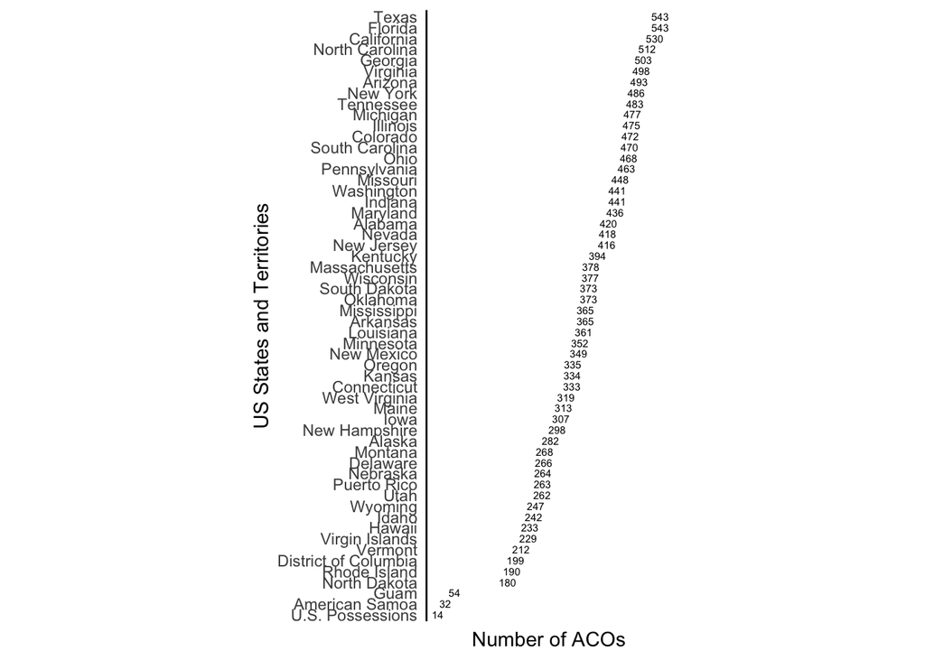

[figure not shown]

We can first choose to look at the total number of assigned beneficiaries per county. The values for this dataset are: (*) = Suppressed (county has between 1 and 10 total assigned beneficiaries or county was selected for complementary supression; see parameters for more information)

What proportion of counties have less than 10 Total Assigned Beneficiaries?

```
## [1] 13
```